# Lecture 10

2022-10-06

## Summary statistics

- In descriptive statistics, summary statistics are used to summarize a set of observations
  - Communicate the largest amount of information as simply as possible
- There are two very important attributes that we try to describe
  - A measure of location or central tendency of the data
    - Mean, median
  - A measure of statistical dispersion or spread
    - Standard deviation, variance, range, interquartile range

## Mean

The mean or average is the sum of a collection of numbers divided by the count of numbers in the collection.

```r
a <- c(1,1,2,2,3,3,3,3,3,4,5,6)
b <- c(-3,2,4,2,5,-6,1,2,2,4,4,-2)
mean(a)
```

```
## [1] 3
```

```r
mean(b)
```

```
## [1] 1.25
```

## Medians

A median is a value separating the higher half from the lower half of a data sample

```r
median(a)
```

```
## [1] 3
```

```r
median(b)
```

```
## [1] 2
```

## Quantiles

Quantiles are cut points dividing the sample into intervals with pre-specified proportions observations. Quartiles are the three cut points that will divide a dataset into four equal-sized groups.

```r
quantile(a,probs=c(0.25,0.5,0.75))
```

```
##  25%  50%  75%
## 2.00 3.00 3.25
```

```r
quantile(b,probs=c(0.25,0.5,0.75))
```

```
##  25%  50%  75%
## 0.25 2.00 4.00
```

## Range

The range of a set of data is the difference between the largest and smallest values

```r
range(a)
```

```
## [1] 1 6
```

```r
range(b)
```

```
## [1] -6  5
```

## Interquartile range

Interquartile range is the difference between the third and the first quartiles.

```r
IQR(a)
```

```
## [1] 1.25
```

```r
IQR(b)
```

```
## [1] 3.75
```

## Variance and standard deviation

Variance is the expectation of the squared deviation of a random variable from its mean. It measures how far a set of numbers are spread out from their average value.

```r
var(a)
```

```
## [1] 2.181818
```

```r
var(b)
```

```
## [1] 10.93182
```

```r
sd(a)
```

```
## [1] 1.477098
```

```r
sd(b)
```

```
## [1] 3.30633
```

## Summary

```r
summary(a)
```

```
##    Min. 1st Qu.  Median    Mean 3rd Qu.    Max.
##    1.00    2.00    3.00    3.00    3.25    6.00
```

```r
summary(b)
```

```
##    Min. 1st Qu.  Median    Mean 3rd Qu.    Max.
##   -6.00    0.25    2.00    1.25    4.00    5.00
```

## Your turn

- Obtain the summary statistics for the variables in diamonds dataset. Does the summary() calculate different summary statistics for different types of variables?
- Calculate the mean, median, variance, and IQR for the following two vector. Explain your findings.

```
    a <- 1:7
    b <- c(1:6, 10000)
```

## Position adjustment

Position adjustments are used to adjust the position of each geom. It contols how overlapping objects are arranged. There are five different adjustments

- “identity”: default of most geoms
- “jitter”: default of geom_jitter()
- “dodge” default of geom_boxplot()
- “stack” default of geom_bar() and geom_histogram()
- “fill”: useful for geom_bar() and geom_histogram()

## Position adjustment

In the following plot, each colored rectangle represents a combination of cut and clarity

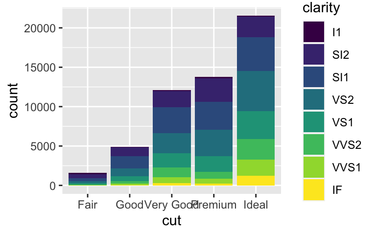

```r
ggplot(data = diamonds) +
  geom_bar(mapping = aes(x = cut, fill = clarity))
```

## Position adjustment

The stacking is performed automatically by the position adjustment specified by the position argument.

```
ggplot(data = diamonds) +
  geom_bar(mapping = aes(x = cut, fill = clarity), position = "fill")

ggplot(data = diamonds) +
  geom_bar(mapping = aes(x = cut, fill = clarity), position = "dodge")
```

## Position adjustment

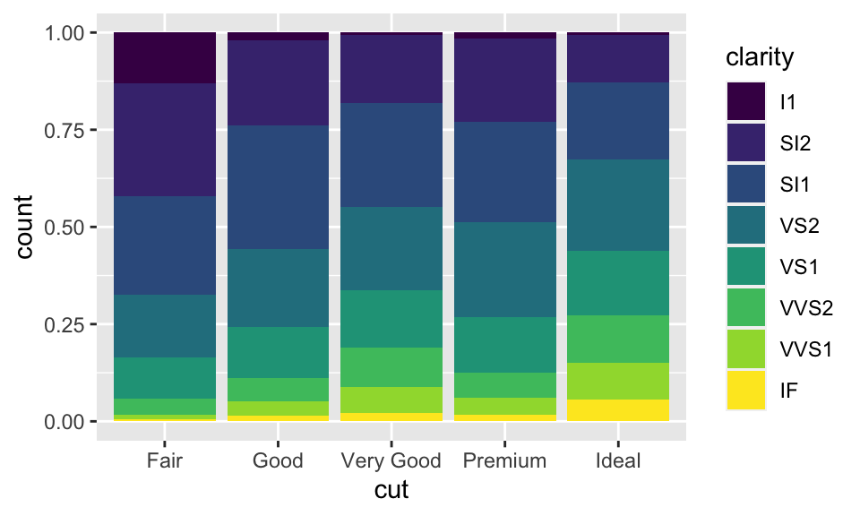

```r
ggplot(data = diamonds) +
  geom_bar(mapping = aes(x = cut, fill = clarity), position = "fill")
```

## Position adjustment

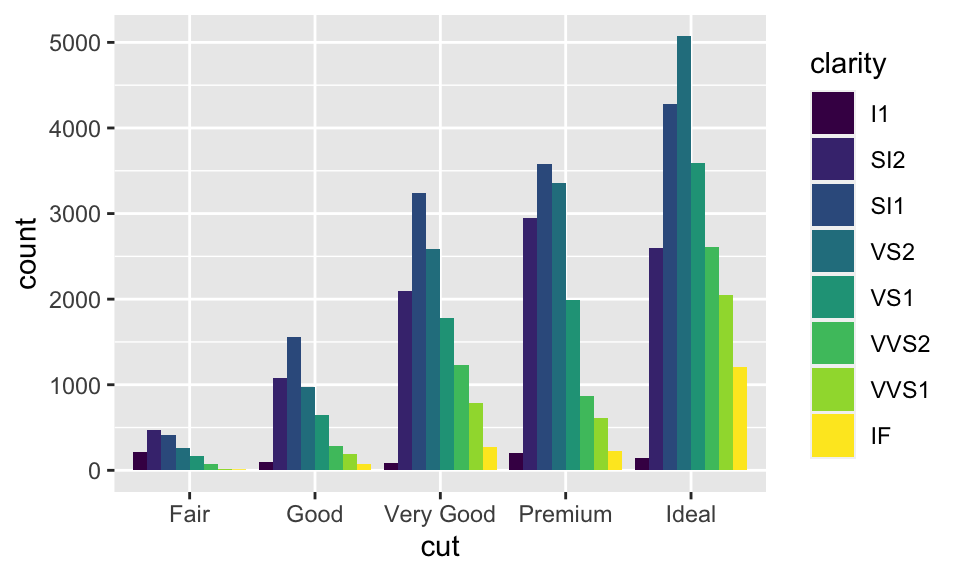

```r
ggplot(data = diamonds) +
  geom_bar(mapping = aes(x = cut, fill = clarity), position = "dodge")
```

## Your turn

- Create barplots for color of the diamonds dataset split by cut:
  - Compare the number of different levels of cut within each value of color
  - Compare the proportions of different levels of cut across different color
- What’s the default position adjustment for geom_boxplot()? Create a visualization of the mpg dataset that demonstrates it.

## Coordinate Systems

The default coordinate system is the Cartesian coordinate system where the x and y positions act independently to determine the location of each point.

There are a number of other coordinate systems that are occasionally helpful

## `coord_flip()`

`coord_flip()` switches the x and y axes

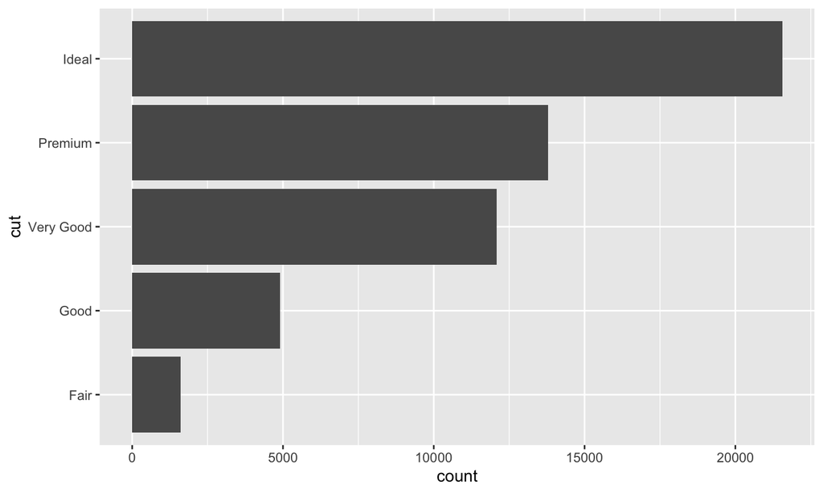

## `coord_polar`

`coord_polar()` uses the polar coordinate system:  
A two-dimensional coordinate system in which each point on a plate is determined by a distance from a reference point and an angle from a reference direction.

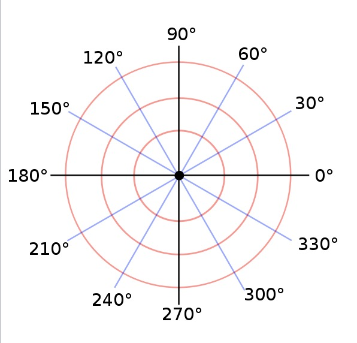

```r
bar <- ggplot(data = diamonds) +
  geom_bar(
    mapping = aes(x = cut, fill = cut),
    show.legend = FALSE,
    width = 1
  ) +
  labs(x = NULL, y = NULL)
```

```r
bar <- ggplot(data = diamonds) +
  geom_bar(
    mapping = aes(x = cut, fill = cut),
    show.legend = FALSE,
    width = 1
  ) +
  labs(x = NULL, y = NULL)

bar + coord_flip()
```

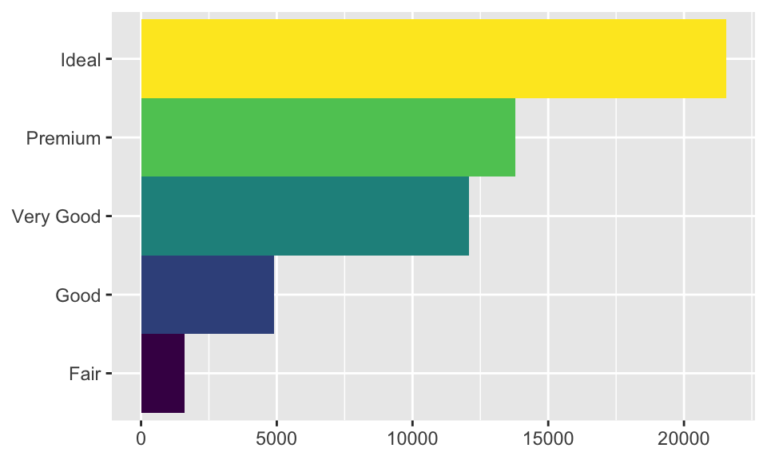

```r
bar <- ggplot(data = diamonds) +
  geom_bar(
    mapping = aes(x = cut, fill = cut),
    show.legend = FALSE,
    width = 1
  ) +
  labs(x = NULL, y = NULL)

bar + coord_flip()
```

```r
bar <- ggplot(data = diamonds) +
  geom_bar(
    mapping = aes(x = cut, fill = cut),
    show.legend = FALSE,
    width = 1
  ) +
  labs(x = NULL, y = NULL)

bar + coord_polar()
```

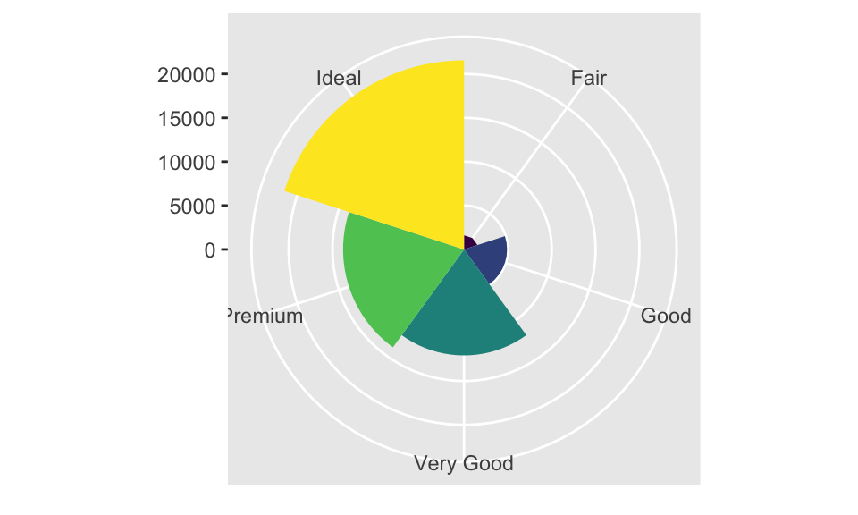

```r
bar <- ggplot(data = diamonds) +
  geom_bar(
    mapping = aes(x = cut, fill = cut),
    show.legend = FALSE,
    width = 1
  ) +
  labs(x = NULL, y = NULL)

bar + coord_polar()
```

## Your turn

- Turn a stacked bar chart into a pie chart using `coord_polar()`
- What does the plot below tell you about the relationship between city and highway mpg?
  - Why is `coord_fixed()` important?
  - What does `geom_abline()` do?

```
ggplot(data = mpg, mapping = aes(x = cty, y = hwy)) +
geom_point() +
geom_abline() +
coord_fixed()
```